# La instrumentalización socio-política del Tribunal Constitucional en Chile: un análisis de las redes sociales que participan en requerimientos de institucionalidad entre 1972 y 2020

Jan Dimter, Cristóbal Ortiz y Martín Venegas

01-11-2020

# **Introducción**

En un contexto de deslegitimación de la democracia liberal, la presente investigación busca aportar evidencia –mediante un análisis de redes sociales– sobre la instrumentalización de las instituciones democráticas chilenas, en este caso, el tribunal constitucional por parte de cierto grupos sociales y políticos minoritarios que actúan en red. Dicho contexto de crisis de la democracia liberal (Castells, 2017) interpela las formas en que se desarrolla la relación entre política y sociedad en el mundo occidental. Así, una hipótesis plausible argumenta que la crisis se debe a la instrumentalización de la institucionalidad democrática por ciertos grupos sociales para sus propios fines. De esta forma, la sociedad deslegitima la política al percibir dicha instrumentalización como injusta y, por tanto, antidemocrática. En ello juega un rol fundamental y específico la instrumentalización de la constitución política de un país, la cual permite frenar o subsumir cualquier cambio político y social a su marco normativo vigente, relegando la capacidad del sistema político a la voluntad de grupos sociales minoritarios.

El caso de la constitución política chilena de 1980 –de origen autoritario, pero cuyo objetivo es la transición democrática— representa uno de los casos paradigmáticos de instrumentalización. Lo anterior ya que si bien contempla una transición donde el propósito es cambiar el régimen autoritario de Pinochet por una democracia, contiene a su vez una impronta autoritaria que la constitución imprime en la correlación de fuerzas políticas venideras: la constitución de 1980 es un enclave autoritario que perdura en democracia (Heiss, 2020). Dicha impronta se expresa en mecanismos institucionales de veto y neutralización susceptibles de apropiación por las fuerzas políticas herederas del régimen autoritario, en desmedro de las fuerzas políticas entrantes (Ginsburg, 2014). Todo lo cual ha impedido la deliberación de las mayorías y la soberanía popular en el periodo postdictadura (Garretón, 2012), enclaustrando el poder decisión y el contenido de las reformas en los principios de visión de grupos minoritarios asociados al régimen, quienes recurren al TC en tanto es uno de los últimos enclaves autoritarios en ejercicio (Atria et al., 2017).

El conflicto anteriormente descrito ha sido ampliamente estudiado en sus causas y elementos. Así, de una parte, ya hemos visto una de las causas que refieren a los mecanismos de veto que permiten a minorías parlamentarias frenar proyectos de cambio a su contraparte mayoritaria en el parlamento e, incluso, al ejecutivo. De otra parte, hay un grupo de estudios que aborda los elementos de la instrumentalización de la constitución, cuyo blanco favorito ha sido el rol del Tribunal Constitucional (TC) y los respectivos requerimientos de inconstitucionalidad por parte de partidos en la revisión de leyes (Atria, 2013). Al respecto, estudios han afirmado que el TC ha sido utilizado por partidos políticos de derecha como mecanismo de veto y neutralización de cambios sociales de corte progresista (Atria, 2013). En lo que respecta al tipo de leyes que se busca vetar o neutralizar, saltan a luz aquellas en materia de cambios al sistema de isapres (Coddou, 2010; Zúñiga, 2011) y educacional (Atria et al., 2017). Finalmente, en materia de impulsores de la instrumentalización los estudios fijan su atención a un partido político heredero del ideario del régimen autoritario chileno: la Unión Demócrata Independiente (Atria et al., 2017; Ginsburg, 2014).

Pese a estos avances, los estudios no especifican cuál es el tipo de derecha que ha presentado requerimientos, en el entendido que ni siquiera la UDI es un grupo homogéneo, así como tampoco un partido político agota la categoría “derecha”. Asimismo, no se ha logrado identificar una tipología de leyes a las que estos grupos se esmeran en vetar, dando simplemente el rótulo de “derechos sociales” (Bassa, 2008) a lo cual la derecha se opone. En suma, si bien existe una idea ampliamente difundida de que el TC es un mecanismo de veto y neutralización favorable a grupos políticos herederos del régimen cívico-militar, no existe una caracterización de estos grupos, ni de las redes sociales mediante las cuales articulan los requerimientos de inconstitucionalidad. En un nivel operativo, podríamos decir que los estudios no se han detenido a analizar las redes de relaciones socio-políticas que permiten la instrumentalización del TC, así como tampoco de la materia sustantiva de las leyes que intenta bloquear la red.

De esta manera, el presente estudio busca dilucidar el entramado social de los arreglos de poder que, en la esfera de la política, recurren al TC con objeto de neutralizar y/o vetar la deliberación socio-política mayoritaria. En concreto se busca responder la pregunta: *¿Cuáles son las redes políticas que se articulan en el proceso de revisión de proyectos de ley, leyes o tratados que han sido declarados inconstitucionales por el Tribunal Constitucional?*

### **Objetivos e hipótesis**

- Objetivo general: Identificar las redes políticas dentro del proceso de revisión de proyectos de ley, leyes o tratados que han sido declarados inconstitucionales por el Tribunal Constitucional.
- Objetivos específicos:
1. Identificar grupos políticos que presentan proyectos de ley, leyes o tratados con carácter constitucional.
2. Identificar grupos políticos que presentan requerimientos de por inconstitucionalidad al Tribunal Constitucional.
3. Identificar los contenidos puestos en requerimiento.
- Hipótesis:

La hipótesis a discutir en este primer avance se enmarca en el segundo objetivo especifico. Considerando los antecedentes planteados, proponemos que los grupos políticos más involucrados en la presentación de requerimientos al Tribunal Constitucional serán aquellos ligados espectro político de Derecha.

# **Método**

# **Resultados**

## Figura 1

[figure not shown]

## Figura 2

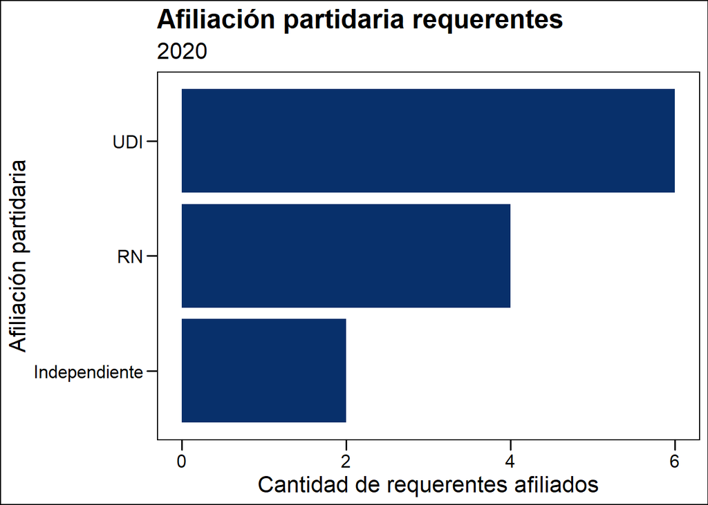

Como es posible observar en la Figura 2, la inmensa mayoría de los senadores y diputados requerentes a la sentencia ocurrida el año 2020 se enmarcan en los partidos políticos de la Derecha chilena: Renovación Nacional y Unidad Democrata Independiente. Por lo que, si bien a un nivel descriptivo aun, los datos van dando soporte a la hipotesis descriptiva presentada en el presente escrito: que los requerimientos son ejercidos desde los grupos políticos más ligados al espectro de Derecha.

## Figura 3

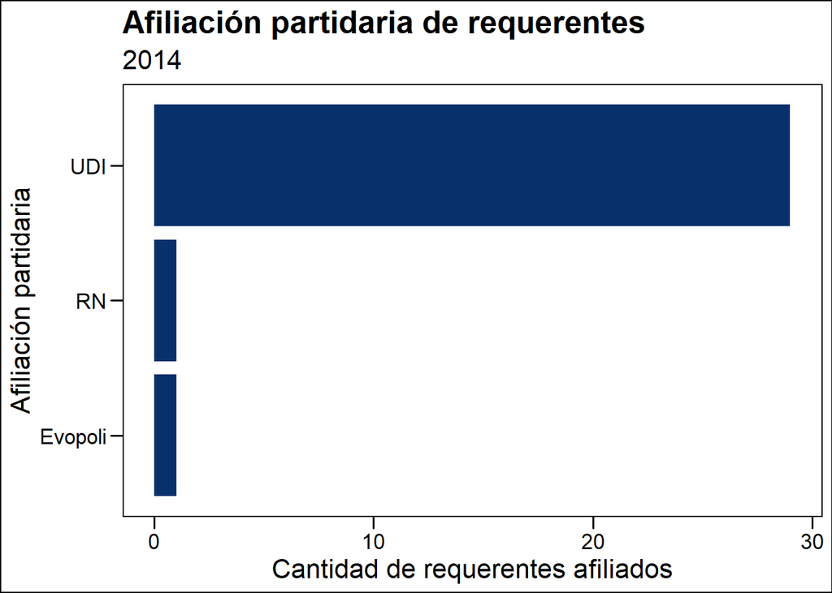

Resulta claro que la totalidad de requirientes ante el TC pertenece a la derecha política chilena, pero sorprende la alta concentración que obtenida a partir de aquellos militantes de la UDI. Esto se condice con la solidez en rechazar la posibilidad de una nueva constitución por parte del partido gremialista, en comparación con la división presentada en otros partidos de derecha

# **Discusión y conclusiones**

En este escrito hemos problematizado la idea de la instrumentalización del Tribunal Constitucional para con los intereses de determinados grupos políticos. Bajo esa idea, nos hemos propuesto la identificación de las redes políticas dentro de los procesos de revisión de los requerimientos presentados al Tribunal Constitucional, para lo cual, este avance aporta en identificación a un nivel descriptivo de aquellos grupos políticos más involucrados en la presentación de requerimientos.

Hemos podido observar que casi en su totalidad, al menos de los dos casos presentados (sentencias del 2014 y el 2020), los requerentes son senadores o diputados ligados al espectro político de derecha. Más aun, aquellos requerentes nombrados independientes, mantienen un historial político asociado a la Derecha, considerando que Carmen Gloria Aravena fue militante Evopoli entre 2016 y 2019 y Kenneth Pugh fue a senador en lista de Chilevamos, independiente apoyado por Renovación Nacional.

Si bien este avance aun en bastante incipiente, en terminos de resultados y sofisticación del metodo, proponemos que la exploración de estas tematicas, sumamente contingentes hoy en dia, son de especial relevancia para las ciencias sociales y pueden abrir nuevas lineas de investigación.

# **Referencias**

Atria, F. (2013). *La constitución tramposa*. LOM Ediciones.

Atria, F., Salgado, C., & Wilenmann, J. (2017). *Democracia y neutralización: origen, desarrollo y solución de la crisis constitucional*. LOM Ediciones.

Bassa, J. M. (2008). El Estado Constitucional de Derecho. Efectos sobre la Constitución vigente y los derechos sociales. *Estudios Constitucionales: Revista Del Centro de Estudios Constitucionales*, *6*(1), 18.

Castells, M. (2017). *Ruptura: la crisis de la democracia liberal*. Alianza Editorial.

Coddou, A. (2010). El nuevo Tribunal Constitucional y los derechos sociales: El caso de las Isapres. *Anuario de Derecho Público 2010*, 55–73.

Garretón, M. A. (2012). *Neoliberalismo corregido y progresismo limitado: Los gobiernos de la Concertación en Chile, 1990-2010*. Editorial Arcis.

Ginsburg, T. (2014). Fruto de la parra envenenada? Algunas observaciones comparadas sobre la Constitución chilena. *Estudios Públicos*, *133*.

Heiss, C. (2020). *Por qué necesitamos una nueva constitución?* Penguin Random House Grupo Editorial Chile.

TC. (2020). Sentencias del Tribunal Constitucional de Chile. In *Tribunal Constitucional Chile*.

Zúñiga, F. (2011). La declaración de incostitucionalidad de la Ley de ISAPRES en el Tribunal Constitucional. *Anuario de Derecho Público*, *1*, 54–95.